# Generalized linear mixed models in R: nitty-gritty

Ben Bolker

24 June 2023

Licensed under the [Creative Commons attribution-noncommercial license](http://creativecommons.org/licenses/by-nc/3.0/). Please share & remix noncommercially, mentioning its origin.

```r
library(lme4)
library(broom)
library(broom.mixed)
library(dotwhisker)
```

## Overview

Most aspects of GLMMs are carried over from LMMs (random effects) and GLMs (families and links).

## integration methods

You do have to decide on an approximation method.

- penalized quasi-likelihood
  - fastest/least accurate
  - uses quasi-likelihood (no AIC etc.?)
- Laplace approximation
  - fast, flexible compromise
- adaptive Gauss-Hermite quadrature
  - slowest
  - most accurate
  - most limited

In `lme4`, use the `nAGQ=` argument; `nAGQ=1` (default) corresponds to Laplace approximation

## integration rules

- it only really matters in relatively extreme cases (small numbers of binary obs per group)
- use the most accurate method that’s available and feasible

## Laplace-approximation diagnostics

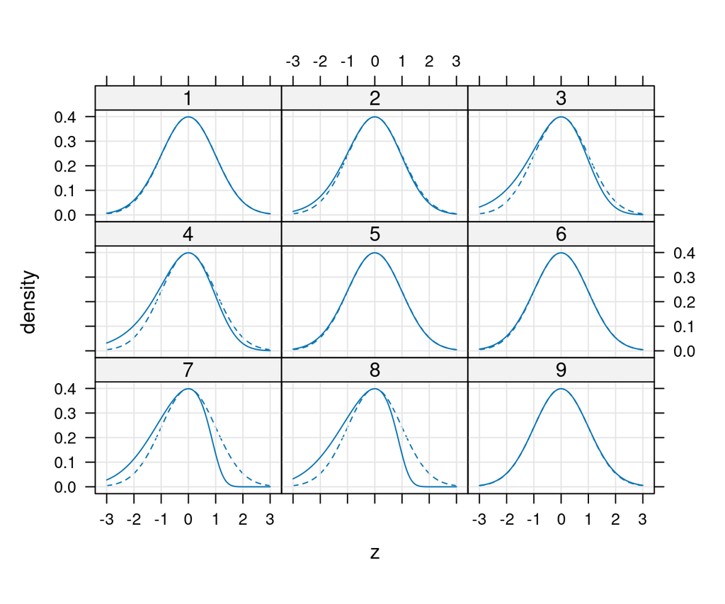

```r
library(lattice)
aspect <- 0.6
xlab <- "z"; ylab <- "density"; type <- c("g","l"); scaled <- FALSE
mm <- readRDS("../../data/toenail_lapldiag.rds")
print(xyplot(y ~ zvals|id, data=mm,
             type=type, aspect=aspect,
             xlab=xlab,ylab=ylab,
             as.table=TRUE,
             panel=function(x,y,...){
    if (!scaled) {
        panel.lines(x, dnorm(x), lty=2)
    } else {
        panel.abline(h=1, lty=2)
    }
    panel.xyplot(x,y,...)
}))
```

## comparing integration methods

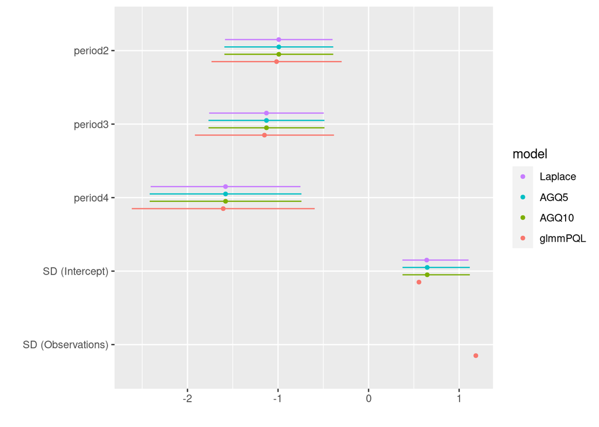

```r
g1 <- glmer(incidence/size ~ period + (1|herd),
            family=binomial,
            data=cbpp,
            weights=size)
g2 <- update(g1,nAGQ=5)
g3 <- update(g1,nAGQ=10)
g4 <- MASS:::glmmPQL(incidence/size ~ period,
                     random = ~1|herd,
                     data=cbpp,
                     family=binomial,
                     weights=size,
                     verbose=FALSE)
dwplot(list(Laplace=g1,AGQ5=g2,AGQ10=g3,glmmPQL=g4))
```

## overdispersion

```r
aods3::gof(g1)
```

```
## D  = 73.4743, df = 51, P(>D) = 0.02133054
## X2 = 63.0674, df = 51, P(>X2) = 0.1196646
```

## dealing with overdispersion

- quasi-likelihood
- observation-level random effects (Elston et al. 2001)
- overdispersed distributions  
  (negative binomial, beta-binomial, etc.)  
  `glmmTMB`/`brms` (Brooks et al. 2017)

```r
library(glmmTMB)
g5 <- glmmTMB(incidence/size ~ period + (1|herd),
              family=binomial,
              data=cbpp,
              weights=size)
g6 <- update(g5, family=betabinomial)
```

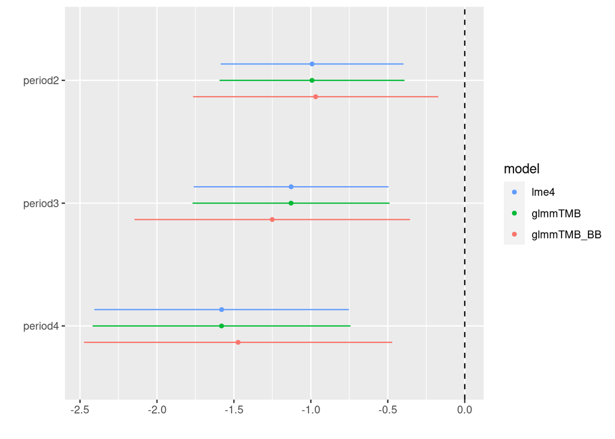

```r
dotwhisker::dwplot(list(lme4=g1,glmmTMB=g5,glmmTMB_BB=g6),
                   effects="fixed")+
    geom_vline(xintercept=0,linetype=2)
```

## other diagnostics

- assumption of Normal residuals may not be very good
- simulated residuals (`DHARMa`)

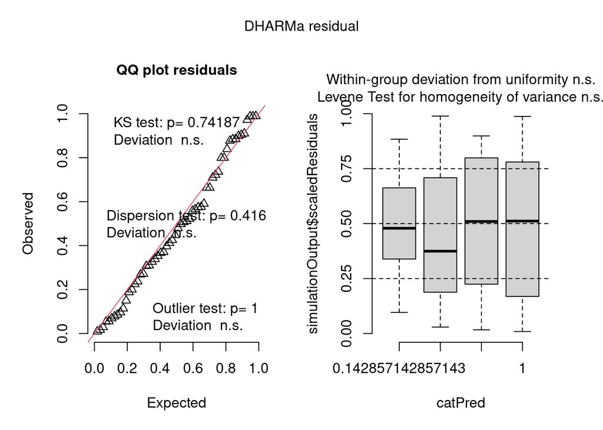

```r
DHARMa::simulateResiduals(g1,plot=TRUE)
```

## zero-inflation

```r
zipm3 <- glmmTMB(count~spp * mined + (1|site),
                ziformula=~spp * mined,
                Salamanders, family="poisson")
## can even include random effects in zero-inflation model!
zipm4 <- update(zipm3, ziformula = ~spp*mined+(1|site))
zipm5 <- update(zipm3, ziformula = ~(1|site))

library(bbmle)
AICtab(zipm3,zipm4,zipm5)
```

```
##       dAIC df
## zipm4  0.0 30
## zipm3 25.9 29
## zipm5 28.1 17
```

Brooks, Mollie E., Kasper Kristensen, Koen J. van Benthem, Arni Magnusson, Casper W. Berg, Anders Nielsen, Hans J. Skaug, Martin Mächler, and Benjamin M. Bolker. 2017. “glmmTMB Balances Speed and Flexibility Among Packages for Zero-Inflated Generalized Linear Mixed Modeling.” *R Journal* 9 (2): 378–400. https://journal.r-project.org/archive/2017/RJ-2017-066/RJ-2017-066.pdf.

Elston, D. A., R. Moss, T. Boulinier, C. Arrowsmith, and X. Lambin. 2001. “Analysis of Aggregation, a Worked Example: Numbers of Ticks on Red Grouse Chicks.” *Parasitology* 122 (5): 563–69.